# Data606hw4

Anthony Pagan

October 19, 2018

## Week 4 Homework

4.4 Heights of adults. Researchers studying anthropometry collected body girth measurements and skeletal diameter measurements, as well as age, weight, height and gender, for 507 physically active individuals. The histogram below shows the sample distribution of heights in centimeters. (a) What is the point estimate for the average height of active individuals? What about the median?

#### The point estimate of the average heighs of active individuals is 171.1. The median height is 170.3

2. What is the point estimate for the standard deviation of the heights of active individuals? What about the IQR?

#### The point estimate for the standard deviation of active individuals is 9.4. The IQR is 14

3. Is a person who is 1m 80cm (180 cm) tall considered unusually tall? And is a person who is 1m 55cm (155cm) considered unusually short? Explain your reasoning.

#### 95% confidence of the sample true average should fall within 2 standard deviations. In this case it is between 152.3 and 189.9. Both 155cm and 180cm fall within a normal range and are therefore not unusually short or tall.

4. The researchers take another random sample of physically active individuals. Would you expect the mean and the standard deviation of this new sample to be the ones given above? Explain your reasoning.

#### The expectation is the new mean and standard deviations will vary, but will be within the same range as the first. The samples should fall witin the population mean and standard deviation.

5. The sample means obtained are point estimates for the mean height of all active individuals, if the sample of individuals is equivalent to a simple random sample. What measure do we use to quantify the variability of such an estimate (Hint: recall that SD¯ x = pn)? Compute this quantity using the data from the original sample under the condition that the data are a simple random sample.

#### To get variability we would use the variance. The variance is the the Standard Deviation squared with in this case is 88.36

4.14 Thanksgiving spending, Part I. The 2009 holiday retail season, which kicked o??? on November 27, 2009 (the day after Thanksgiving), had been marked by somewhat lower self-reported consumer spending than was seen during the comparable period in 2008. To get an estimate of consumer spending, 436 randomly sampled American adults were surveyed. Daily consumer spending for the six-day period after Thanksgiving, spanning the Black Friday weekend and Cyber Monday, averaged $84.71. A 95% con???dence interval based on this sample is ($80.31, $89.11). Determine whether the following statements are true or false, and explain your reasoning.

1. We are 95% con???dent that the average spending of these 436 American adults is between $80.31 and $89.11.

#### This statement is true. The confidence interval tells us how confident we are that the average spending range will be between 80.31-89.11

2. This con???dence interval is not valid since the distribution of spending in the sample is right skewed.

#### This distribution is slightly skewed and has a sample of more than 30 so it is valid. It would be invalid if the distribution was extremely right skewed

3. 95% of random samples have a sample mean between $80.31 and $89.11.

#### This stating is true. It is the same as A , mean and average are the same.

4. We are 95% con???dent that the average spending of all American adults is between $80.31 and $89.11.

#### The spending of all American should fall within this range as it was a random sample. If the sample was increase the range should narrow.

5. A 90% con???dence interval would be narrower than the 95% con???dence interval since we don’t need to be as sure about our estimate. ####True a smaller interval will result from a smaller confidence level. A larger confidence will result in a wider interval.
6. In order to decrease the margin of error of a 95% con???dence interval to a third of what it is now, we would need to use a sample 3 times larger.

#### True, as the sample grows larger the sample means is more consistent which results in lower variability and decreases the margin of error.

7. The margin of error is 4.4.

#### That is corect. At 95% we are 2 standard deviations away from the mean. The lower range is (84.71-80.31)/2 which is 2.2 and the upper range is (84.71-89.11)/2 which is -2.2.

4.24 Gifted children, Part I. Researchers investigating characteristics of gifted children collected data from schools in a large city on a random sample of thirty-six children who were identi???ed as gifted children soon after they reached the age of four. The following histogram shows the distribution of the ages (in months) at which these children ???rst counted to 10 successfully. Also provided are some sample statistics.43 Age child first counted to 10 (in months)

1. Are conditions for inference satis???ed?

#### Yes, the sample size is over 30, although distribution is slightly skewed the sample size is large enough

2. Suppose you read online that children ???rst count to 10 successfully when they are 32 months old, on average. Perform hypothesis test to evaluate if these data provide convincing evidence that the average age at which gifted children ???st count to 10 successfully is less than the general average of 32 months. Use a signi???cance level of 0.10.

```r
sds <- 4.31
sample_mean <- 30.69
se <- sds / sqrt(36)
zs <-(32-sample_mean )/se
pv<-1-pnorm(zs)
```

#### Null hypothesis would < 32 Months. Alternative hypothesis would be > 32 months. The pvalue with significance level of .10 i s0.0341013. The conclusion is 32 months pvalue is less then the .10 significance level and we therefor reject the null hypothesis in favor of the alternate hypothesis.

3. Interpret the p-value in context of the hypothesis test and the data.

#### In this example 0.0341013 is lower than th significance level of .10 and we therefore reject the null hypothesis.

4. Calculate a 90% con???dence interval for the average age at which gifted children ???rst count to 10 successfully.

```r
sds <- 4.31
sample_mean <- 30.69
se <- sds / sqrt(36)
lower <- sample_mean - 1.645 * se
upper <- sample_mean + 1.645 * se
h<-c(lower, upper)
```

#### The range at 90% confidence is 29.5083417, 31.8716583.

5. Do your results from the hypothesis test and the con???dence interval agree? Explain

#### Yes, the test hypothesis rejected the null in favor of the alternative and the confidence level shows 32 is outside the 90% confidence range of 29.5083417, 31.8716583

4.26 Gifted children, Part II. Exercise 4.24 describes a study on gifted children. In this study, along with variables on the children, the researchers also collected data on the mother’s and father’s IQ of the 36 randomly sampled gifted children. The histogram below shows the distribution of mother’s IQ. Also provided are some sample statistics.

1. Perform a hypothesis test to evaluate if these data provide convincing evidence that the average IQ of mothers of gifted children is di???erent than the average IQ for the population at large, which is 100. Use a signi???cance level of 0.10.

```r
sds <- 6.5
sample_mean <- 118.2
se <- sds / sqrt(36)
zs <-(100-sample_mean )/se
pv<-pnorm(zs)
```

#### The null hypothesis is the IQ =100. The Alternative hypothesis is the IQ <> 100 In this example 1.2202210^{-63} is less than the significance level of .10 and we therefore reject the null hypothesis.

2. Calculate a 90% con???dence interval for the average IQ of mothers of gifted children.

```r
sds <- 6.5
sample_mean <- 118.2
se <- sds / sqrt(36)
lower <- sample_mean - 1.645 * se
upper <- sample_mean + 1.645 * se
h<-c(lower, upper)
```

#### We are 90% confident that the average IQ will fall between 116.4179167, 119.9820833. In this case an IQ value of 100 falls outside of our confidence range.

3. Do your results from the hypothesis test and the con???dence interval agree? Explain

#### In this case the confidence interval and hypothesis test does agree. The Hypothesis test rejects the null hypothesis that the average IQ of gifted childrens mothers are = 100. The 90% confidence interval does not have that value in its range.

4.34 CLT. De???ne the term “sampling distribution” of the mean, and describe how the shape, center, and spread of the sampling distribution of the mean change as sample size increases.

#### The sampling distribution takes a random amount of data and checks how they relate statistically to each other. The mean gives a point estimate for all of the data. It lets us know on average what each collected data should be. The center provides the mean , while the spread shows how far the data varies. As the sample size increases the distribution should normalize , the spread should narrow into the center.

4.40 CFLBs. A manufacturer of compact ???uorescent light bulbs advertises that the distribution of the lifespans of these light bulbs is nearly normal with a mean of 9,000 hours and a standard deviation of 1,000 hours.

1. What is the probability that a randomly chosen light bulb lasts more than 10,500 hours?

```r
sds <- 1000
sample_mean <- 9000
se <- sds / sqrt(1)
zs <-(10500-sample_mean )/se
pv1<-pnorm(zs)
```

2. Describe the distribution of the mean lifespan of 15 light bulbs.

#### The distribution of the mean of lifespan of 15 lights bulbs will be skewed is the number of lightbulbs are lower than 30.

3. What is the probability that the mean lifespan of 15 randomly chosen light bulbs is more than 10,500 hours?

```r
sds <- 1000
sample_mean <- 9000
se <- sds / sqrt(15)
zs <-(10500-sample_mean )/se
pv<-1-pnorm(zs)
```

#### The probility that 15 randmonly chosen light bulbs is more than 10500 hours is 3.133452210^{-9}

4. Sketch the two distributions (population and sampling) on the same scale.

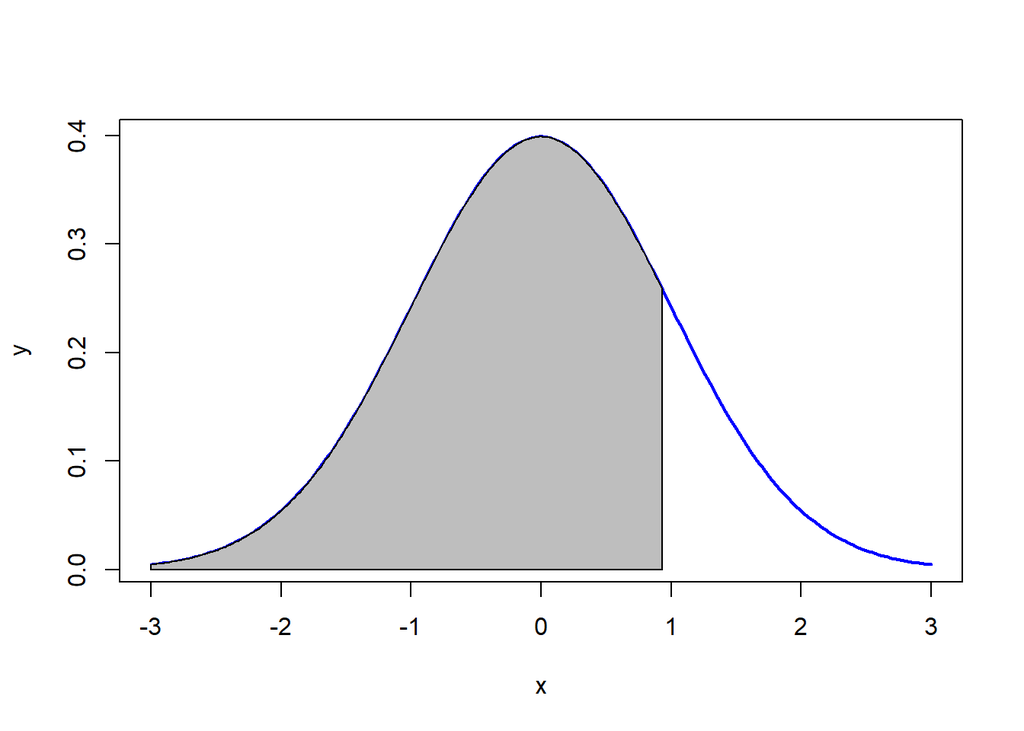

```r
x=seq(-3,3,length=200)
y=dnorm(x)
plot(x,y,type="l", lwd=2, col="blue")
x=seq(-3,pv1,length=200)
y=dnorm(x)
polygon(c(-3,x,pv1),c(0,y,0),col="gray")
```

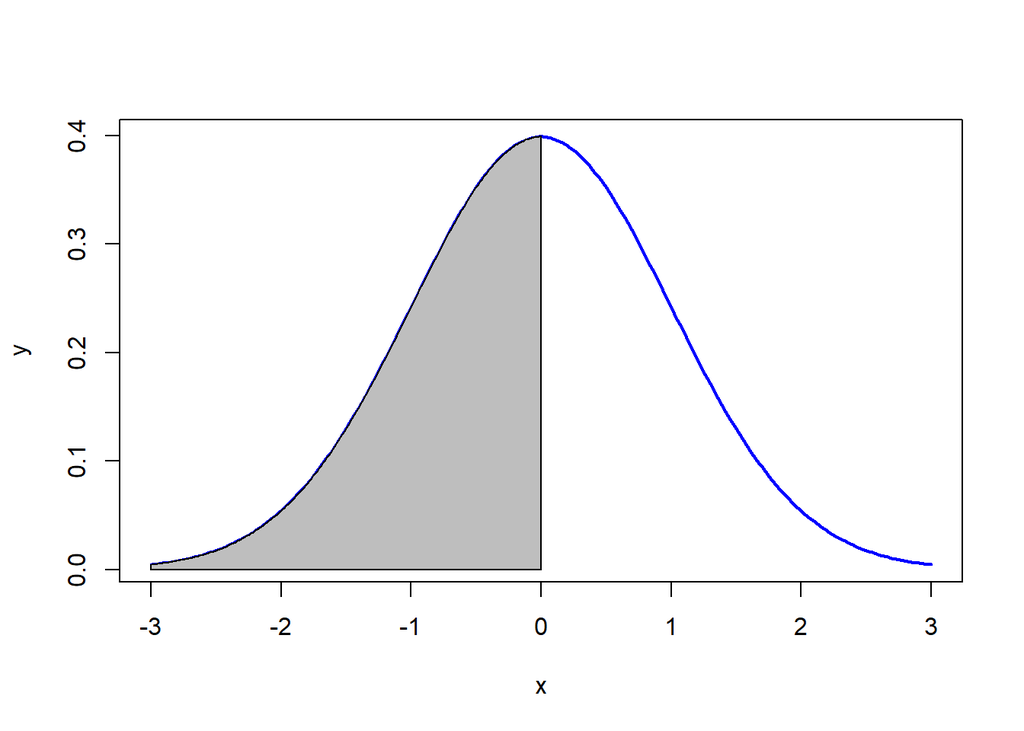

```r
x=seq(-3,3,length=200)
y=dnorm(x)
plot(x,y,type="l", lwd=2, col="blue")
x=seq(-3,pv,length=200)
y=dnorm(x)
polygon(c(-3,x,pv),c(0,y,0),col="gray")
```

5. Could you estimate the probabilities from parts (a) and (c) if the lifespans of light bulbs had a skewed distribution?

#### The skewed distribution would need larger sample sizes to estimate, and will need beta values as well as alpha values to calculate.

4.48 Same observation, di???erent sample size. Suppose you conduct a hypothesis test based on a sample where the sample size is n = 50, and arrive at a p-value of 0.08. You then refer back to your notes and discover that you made a careless mistake, the sample size should have been n = 500. Will your p-value increase, decrease, or stay the same? Explain.

#### The increase in sample size can lower the p-value if the null hypothesis is false. In this scenerio , your are proving the alternate hypothesis is true at a specific p-value. Larger sample sizes p-value will vary less than smaller sample sizes.